# Flexible Survival Analysis and Extrapolation

Fitting Standard and Flexible Parametric Models for Economic Evaluation

Author

Xiaoge Zhang

Published

May 14, 2026

## 1 Executive Summary

Survival extrapolation is one of the most critical skills for a HEOR statistician. Clinical trials usually have limited follow-up, but cost-effectiveness models (like Markov or Partitioned Survival Models) require survival probabilities projected over a lifetime horizon (e.g., 20 or 30 years).

## 2 Mock Data Generation

We simulate a trial with 400 patients, where the **true** survival distribution follows a **Log-normal** shape (hazard increases first, then decreases). This non-monotonic hazard is typical in many disease areas and often cannot be captured well by simple models like the Exponential or Weibull.

```r
library(flexsurv)
library(survival)
library(ggplot2)
library(dplyr)

set.seed(2026)
n <- 400

# Generate Log-normal survival times
t_ctrl <- rlnorm(n / 2, meanlog = 1.5, sdlog = 0.8)
t_trt <- rlnorm(n / 2, meanlog = 2.0, sdlog = 0.6)

df <- data.frame(
    time = c(t_ctrl, t_trt),
    status = 1, # All experience the event initially
    trt = rep(c("Control", "Treatment"), each = n / 2)
)

# Add administrative censoring at t = 15 (end of trial follow-up)
df$status[df$time > 15] <- 0
df$time[df$time > 15] <- 15

# Create survival object
surv_obj <- Surv(df$time, df$status)
```

Let’s look at the Kaplan-Meier curve of our simulated data:

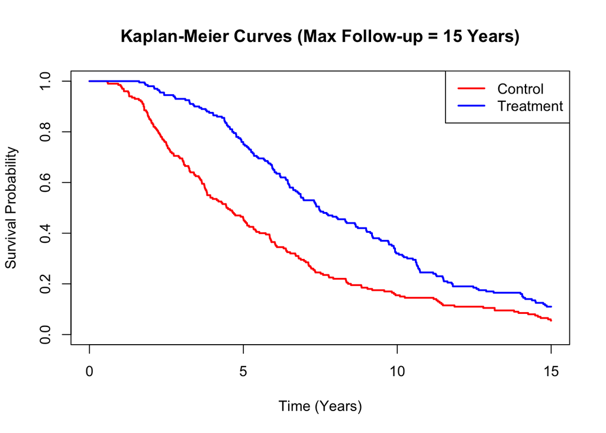

```r
km_fit <- survfit(surv_obj ~ trt, data = df)
plot(km_fit,
    col = c("red", "blue"), lty = 1, lwd = 2,
    xlab = "Time (Years)", ylab = "Survival Probability",
    main = "Kaplan-Meier Curves (Max Follow-up = 15 Years)"
)
legend("topright", legend = c("Control", "Treatment"), col = c("red", "blue"), lty = 1, lwd = 2)
```

## 3 Fitting Parametric Models

We will use the `flexsurv` package to fit the models. `flexsurv` is the industry standard because it allows for easy extrapolation and handles complex distributions.

### 3.1 1. Standard Parametric Models

We fit the 6 standard distributions recommended by NICE DSU TSD 14.

```r
# 1. Exponential
m_exp <- flexsurvreg(surv_obj ~ trt, data = df, dist = "exp")
# 2. Weibull
m_weibull <- flexsurvreg(surv_obj ~ trt, data = df, dist = "weibull")
# 3. Gompertz
m_gompertz <- flexsurvreg(surv_obj ~ trt, data = df, dist = "gompertz")
# 4. Log-normal
m_lnorm <- flexsurvreg(surv_obj ~ trt, data = df, dist = "lnorm")
# 5. Log-logistic
m_llogis <- flexsurvreg(surv_obj ~ trt, data = df, dist = "llogis")
# 6. Generalized Gamma
m_gamma <- flexsurvreg(surv_obj ~ trt, data = df, dist = "gamma")
```

### 3.2 2. Flexible Parametric Model (FPM)

When standard models fail to capture complex hazard shapes, we use restricted cubic splines on the log cumulative hazard scale. Here we use 1 internal knot (`k = 1`).

```r
m_spline <- flexsurvspline(surv_obj ~ trt, data = df, k = 1)
```

## 4 Model Comparison (AIC/BIC)

We extract the Akaike Information Criterion (AIC) and Bayesian Information Criterion (BIC) to evaluate statistical fit. Lower values indicate better fit.

```r
model_names <- c("Exponential", "Weibull", "Gompertz", "Log-normal", "Log-logistic", "Generalized Gamma", "FPM (Spline k=1)")

aic_vals <- c(m_exp$AIC, m_weibull$AIC, m_gompertz$AIC, m_lnorm$AIC, m_llogis$AIC, m_gamma$AIC, m_spline$AIC)
bic_vals <- c(BIC(m_exp), BIC(m_weibull), BIC(m_gompertz), BIC(m_lnorm), BIC(m_llogis), BIC(m_gamma), BIC(m_spline))

comp_df <- data.frame(
    Model = model_names,
    AIC = round(aic_vals, 2),
    BIC = round(bic_vals, 2)
)

# Rank by AIC
comp_df <- comp_df[order(comp_df$AIC), ]
print(comp_df)
```

```
              Model     AIC     BIC
4        Log-normal 2063.03 2075.01
5      Log-logistic 2067.48 2079.45
6 Generalized Gamma 2081.35 2093.32
7  FPM (Spline k=1) 2087.24 2103.21
2           Weibull 2102.50 2114.48
3          Gompertz 2147.41 2159.39
1       Exponential 2209.95 2217.93
```

## 5 Survival Extrapolation (Extending to 30 Years)

Now we use the fitted models to predict survival up to 30 years, doubling the trial’s follow-up period. This is where the models will diverge significantly.

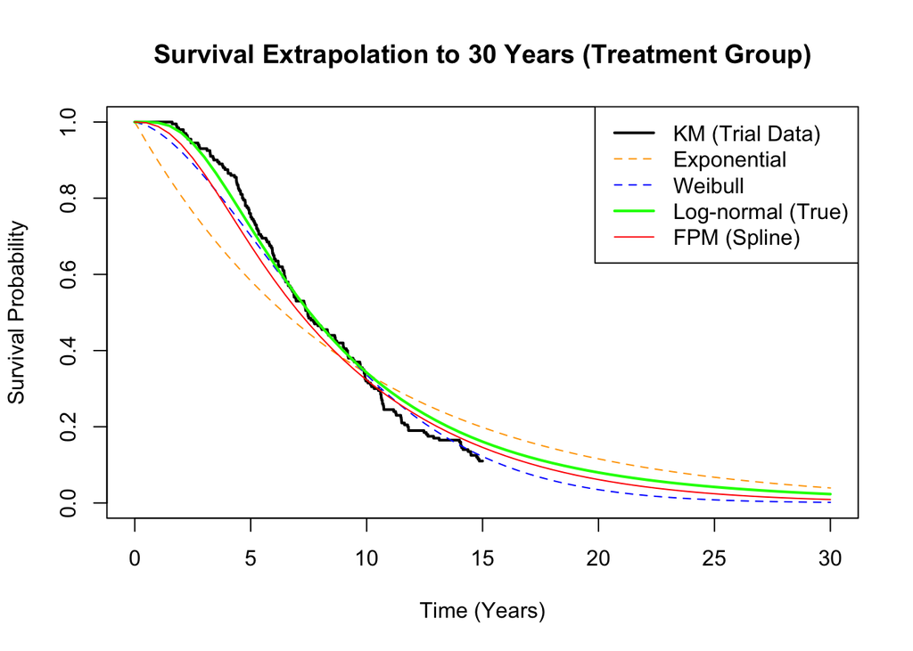

```r
# Generate a sequence of time points up to 30 years
t_extrap <- seq(0, 30, by = 0.5)

# Extract survival predictions for the Treatment group
get_surv <- function(model, times) {
    sum_obj <- summary(model, t = times, newdata = data.frame(trt = "Treatment"))
    return(sum_obj[[1]]$est)
}

plot(km_fit[2],
    col = "black", lwd = 2, conf.int = FALSE,
    xlim = c(0, 30), ylim = c(0, 1),
    xlab = "Time (Years)", ylab = "Survival Probability",
    main = "Survival Extrapolation to 30 Years (Treatment Group)"
)

lines(t_extrap, get_surv(m_exp, t_extrap), col = "orange", lty = 2)
lines(t_extrap, get_surv(m_weibull, t_extrap), col = "blue", lty = 2)
lines(t_extrap, get_surv(m_lnorm, t_extrap), col = "green", lty = 1, lwd = 2) # True model
lines(t_extrap, get_surv(m_spline, t_extrap), col = "red", lty = 1)

legend("topright",
    legend = c("KM (Trial Data)", "Exponential", "Weibull", "Log-normal (True)", "FPM (Spline)"),
    col = c("black", "orange", "blue", "green", "red"),
    lty = c(1, 2, 2, 1, 1), lwd = c(2, 1, 1, 2, 1)
)
```

## 6 Audit Point: Clinical Plausibility > Statistical Fit

When submitting survival extrapolations to HTA bodies like NICE, the model with the lowest AIC/BIC is **not** automatically accepted. Reviewers look for clinical plausibility:

1. **The Tail Behavior**: Models like Log-normal and Log-logistic have heavy tails. They may predict that a significant proportion of patients are “cured” or live for a very long time. If clinicians state that this disease is universally fatal by year 10, a Log-normal model with 20% survival at year 20 will be rejected, regardless of its superior AIC score.
2. **Extrapolation Risk**: FPMs (Splines) are excellent at fitting the trial data (interpolation), but they can behave wildly outside the data range (extrapolation). Always inspect the hazard plots of spline models to ensure they do not exhibit non-biological oscillations in the long term.

In practice, a structured assessment involving: - Visual inspection of fit. - Statistical criteria (AIC/BIC). - Clinical expert opinion on long-term survival. …is mandatory for any credible HTA submission.